# algaeBlossoms

Meetali Bhiwandkar

2/20/2019

Predicting when does the algae blossoms algaeDataset is our Dataset name

```r
library(DMwR)
algaeDataset <- algae
```

From the below summary we can observe that during the winter season maximum water samples has been taken, also from the chemical parameters summary we undertand that we have some NA’s value

```r
summary(algaeDataset)
```

```
##     season       size       speed         mxPH            mnO2
##  autumn:40   large :45   high  :84   Min.   :5.600   Min.   : 1.500
##  spring:53   medium:84   low   :33   1st Qu.:7.700   1st Qu.: 7.725
##  summer:45   small :71   medium:83   Median :8.060   Median : 9.800
##  winter:62                           Mean   :8.012   Mean   : 9.118
##                                      3rd Qu.:8.400   3rd Qu.:10.800
##                                      Max.   :9.700   Max.   :13.400
##                                      NA's   :1       NA's   :2
##        Cl               NO3              NH4                oPO4
##  Min.   :  0.222   Min.   : 0.050   Min.   :    5.00   Min.   :  1.00
##  1st Qu.: 10.981   1st Qu.: 1.296   1st Qu.:   38.33   1st Qu.: 15.70
##  Median : 32.730   Median : 2.675   Median :  103.17   Median : 40.15
##  Mean   : 43.636   Mean   : 3.282   Mean   :  501.30   Mean   : 73.59
##  3rd Qu.: 57.824   3rd Qu.: 4.446   3rd Qu.:  226.95   3rd Qu.: 99.33
##  Max.   :391.500   Max.   :45.650   Max.   :24064.00   Max.   :564.60
##  NA's   :10        NA's   :2        NA's   :2          NA's   :2
##       PO4              Chla               a1              a2
##  Min.   :  1.00   Min.   :  0.200   Min.   : 0.00   Min.   : 0.000
##  1st Qu.: 41.38   1st Qu.:  2.000   1st Qu.: 1.50   1st Qu.: 0.000
##  Median :103.29   Median :  5.475   Median : 6.95   Median : 3.000
##  Mean   :137.88   Mean   : 13.971   Mean   :16.92   Mean   : 7.458
##  3rd Qu.:213.75   3rd Qu.: 18.308   3rd Qu.:24.80   3rd Qu.:11.375
##  Max.   :771.60   Max.   :110.456   Max.   :89.80   Max.   :72.600
##  NA's   :2        NA's   :12
##        a3               a4               a5               a6
##  Min.   : 0.000   Min.   : 0.000   Min.   : 0.000   Min.   : 0.000
##  1st Qu.: 0.000   1st Qu.: 0.000   1st Qu.: 0.000   1st Qu.: 0.000
##  Median : 1.550   Median : 0.000   Median : 1.900   Median : 0.000
##  Mean   : 4.309   Mean   : 1.992   Mean   : 5.064   Mean   : 5.964
##  3rd Qu.: 4.925   3rd Qu.: 2.400   3rd Qu.: 7.500   3rd Qu.: 6.925
##  Max.   :42.800   Max.   :44.600   Max.   :44.400   Max.   :77.600
##
##        a7
##  Min.   : 0.000
##  1st Qu.: 0.000
##  Median : 1.000
##  Mean   : 2.495
##  3rd Qu.: 2.400
##  Max.   :31.600
##
```

Removing the NA from the dataset

```r
algaeDataset <- na.omit(algaeDataset)
```

# Visualizing the algae blossoms

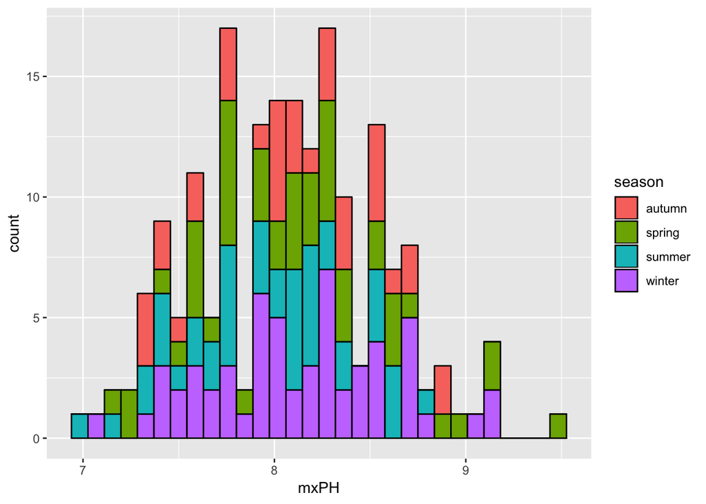

```r
library(ggplot2)
ggplot(algaeDataset,aes(mxPH,fill = season)) + geom_histogram(colour = "black")
```

As we can see from the boxplot, we have a lot of outliers thus concluding that these values must have a lot of effect on the orthophoshate chemical count of the river

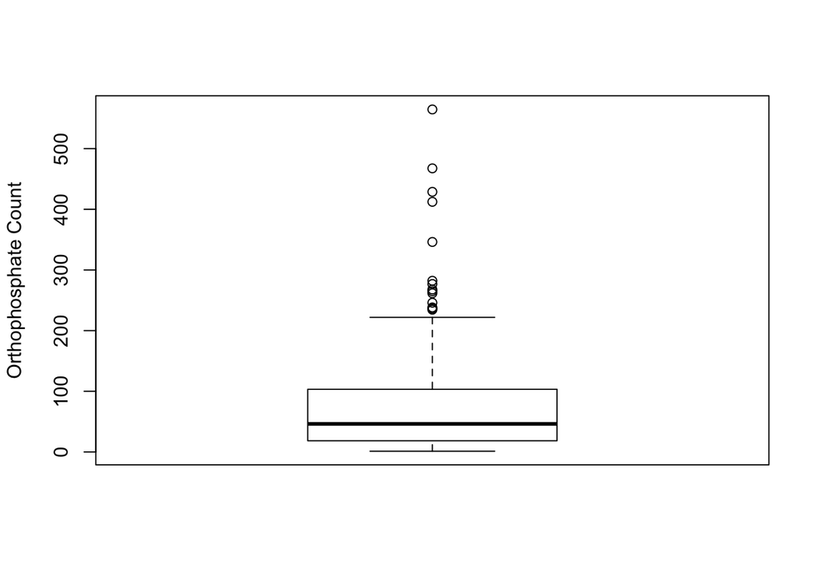

```r
boxplot(algaeDataset$oPO4, ylab="Orthophosphate Count")
```

As we can see from the below graph that maximum times when the size of the river is medium we have taken the samples to identify the algae blossoms

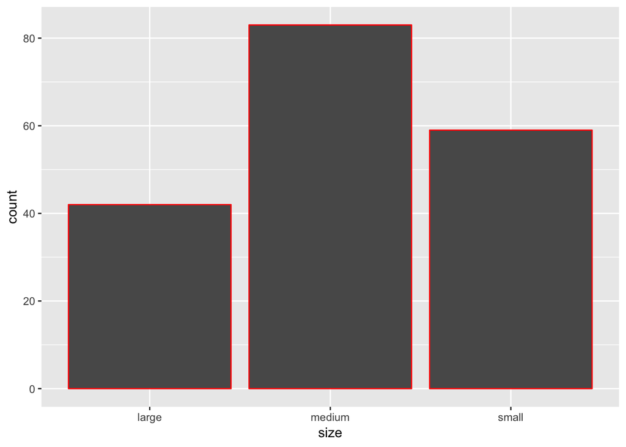

```r
ggplot(algaeDataset,aes(x=size)) + geom_bar(colour = "Red")
```

Here we are doing a bivariate boxplot which is helping us to understand about algae 1 that in what kind of the size of the river does it blossom more, so here we say that when the river size is small algae 1 blossoms a lot and we also see lot of outliers river size is medium

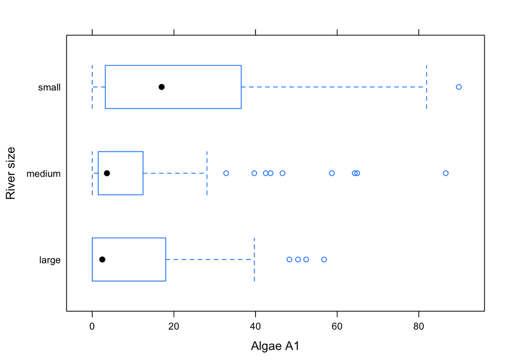

```r
library(lattice)
bwplot(size~a1,data=algaeDataset,xlab = "Algae A1",ylab = "River size")
```

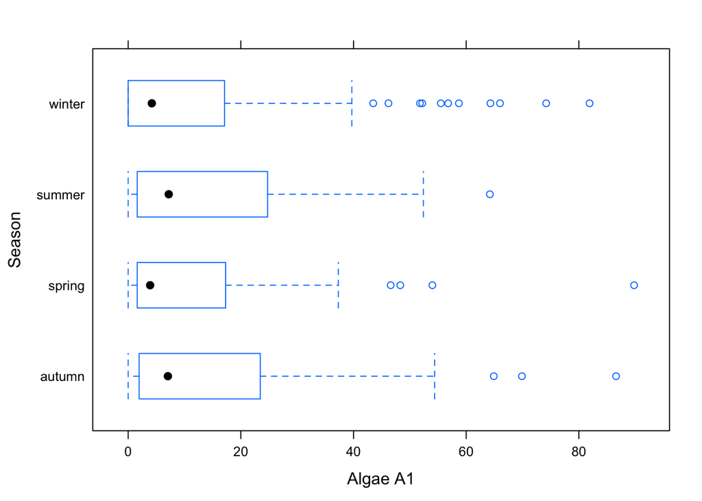

```r
bwplot(season~a1,data=algaeDataset,xlab = "Algae A1",ylab = "Season")
```

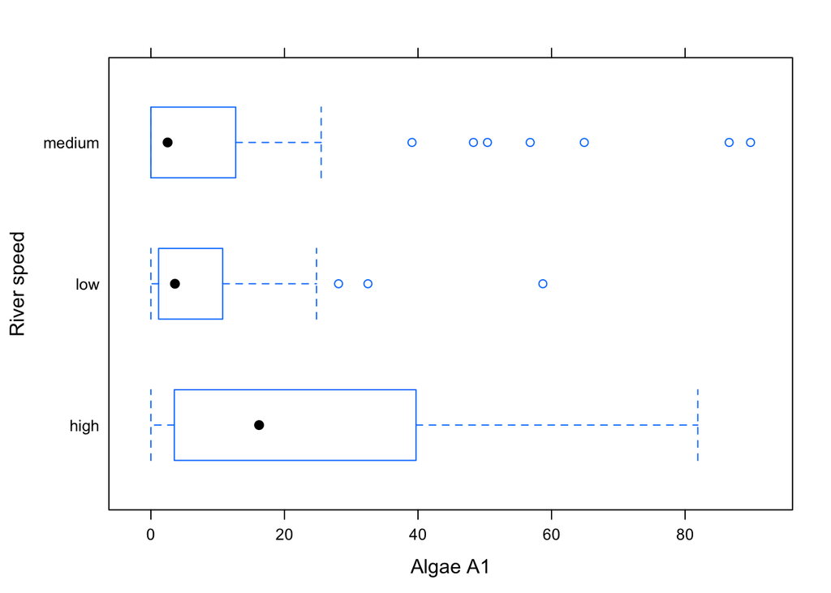

```r
bwplot(speed~a1,data=algaeDataset,xlab = "Algae A1",ylab = "River speed")
```

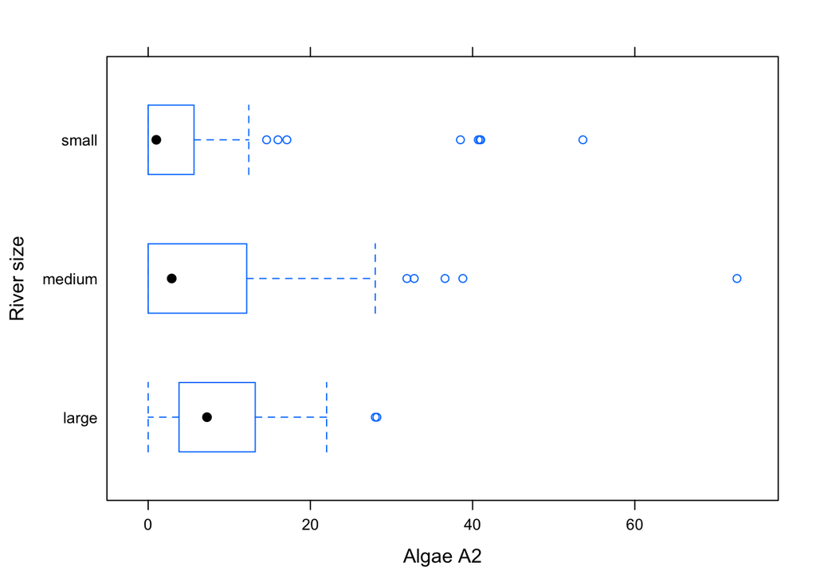

```r
bwplot(size~a2,data=algaeDataset,xlab = "Algae A2",ylab = "River size")
```

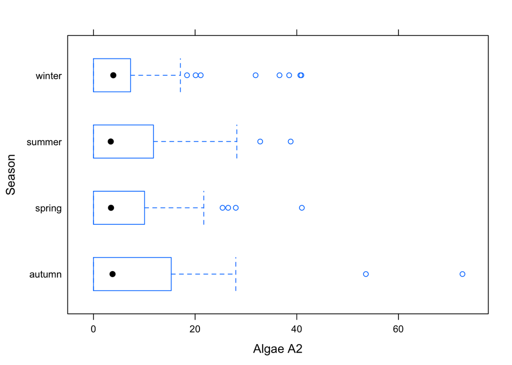

```r
bwplot(season~a2,data=algaeDataset,xlab = "Algae A2",ylab = "Season")
```

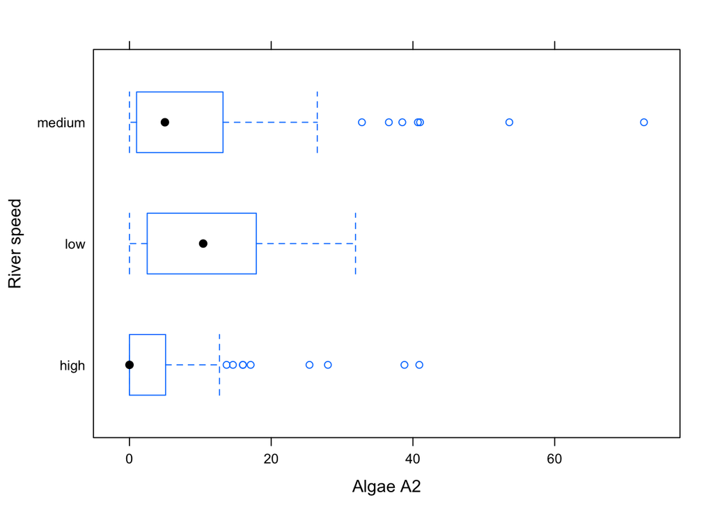

```r
bwplot(speed~a2,data=algaeDataset,xlab = "Algae A2",ylab = "River speed")
```

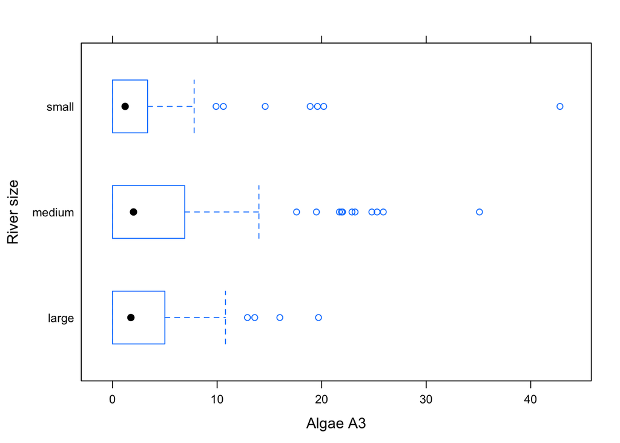

```r
bwplot(size~a3,data=algaeDataset,xlab = "Algae A3",ylab = "River size")
```

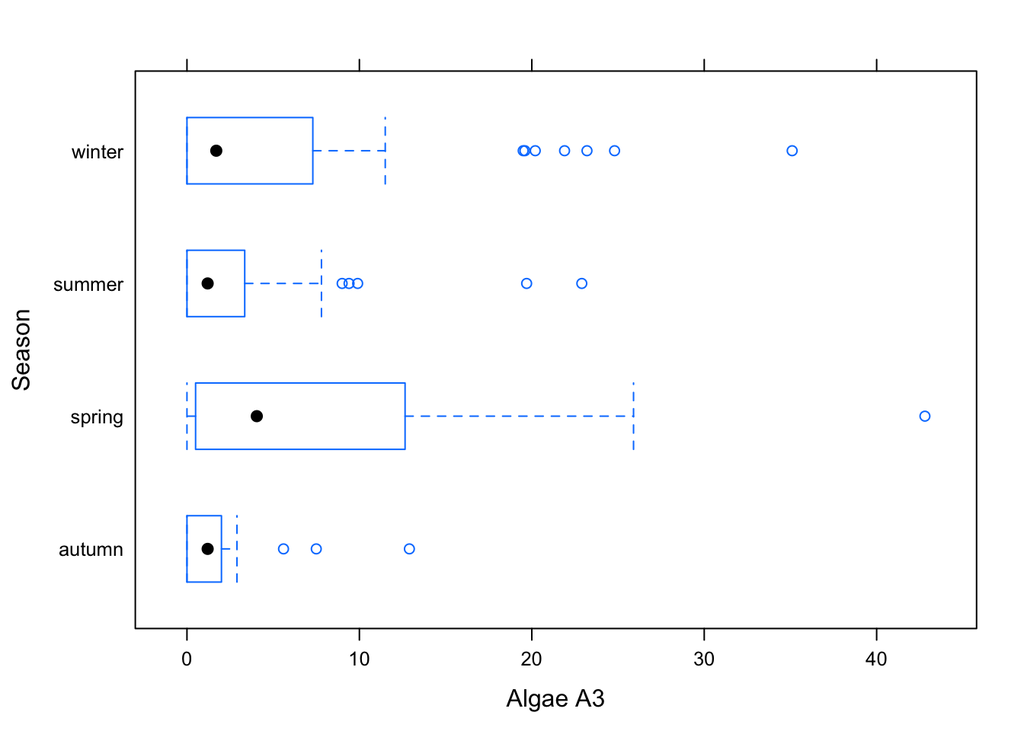

```r
bwplot(season~a3,data=algaeDataset,xlab = "Algae A3",ylab = "Season")
```

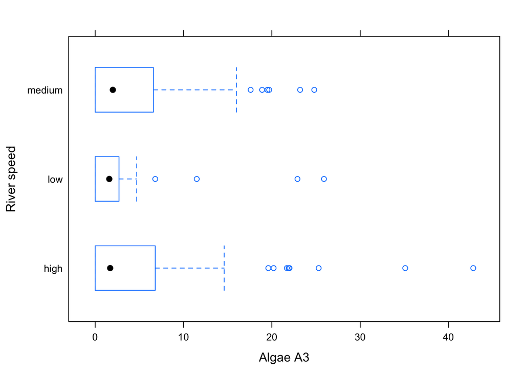

```r
bwplot(speed~a3,data=algaeDataset,xlab = "Algae A3",ylab = "River speed")
```

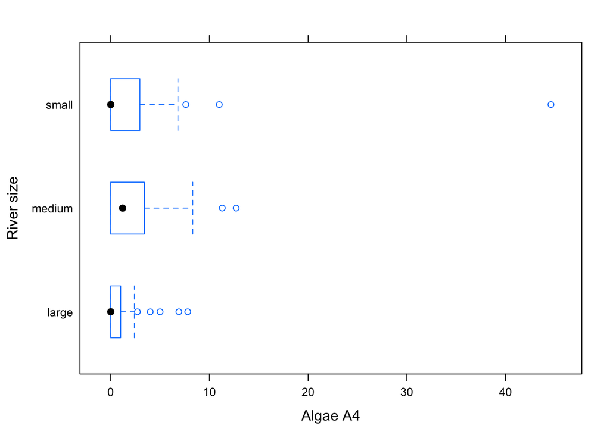

```r
bwplot(size~a4,data=algaeDataset,xlab = "Algae A4",ylab = "River size")
```

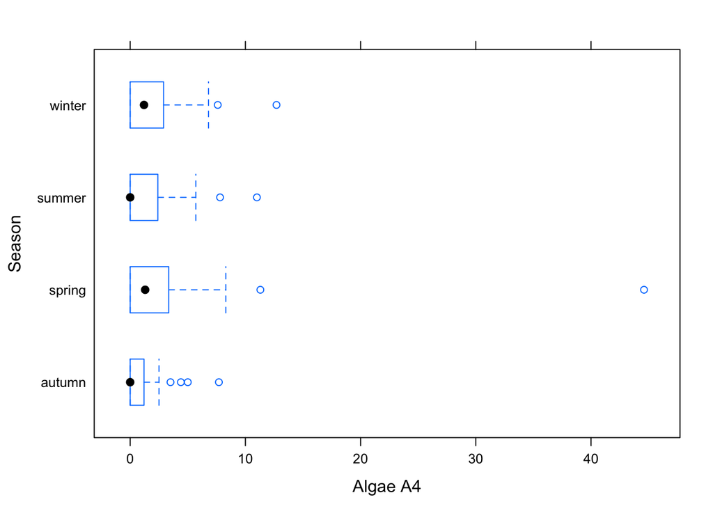

```r
bwplot(season~a4,data=algaeDataset,xlab = "Algae A4",ylab = "Season")
```

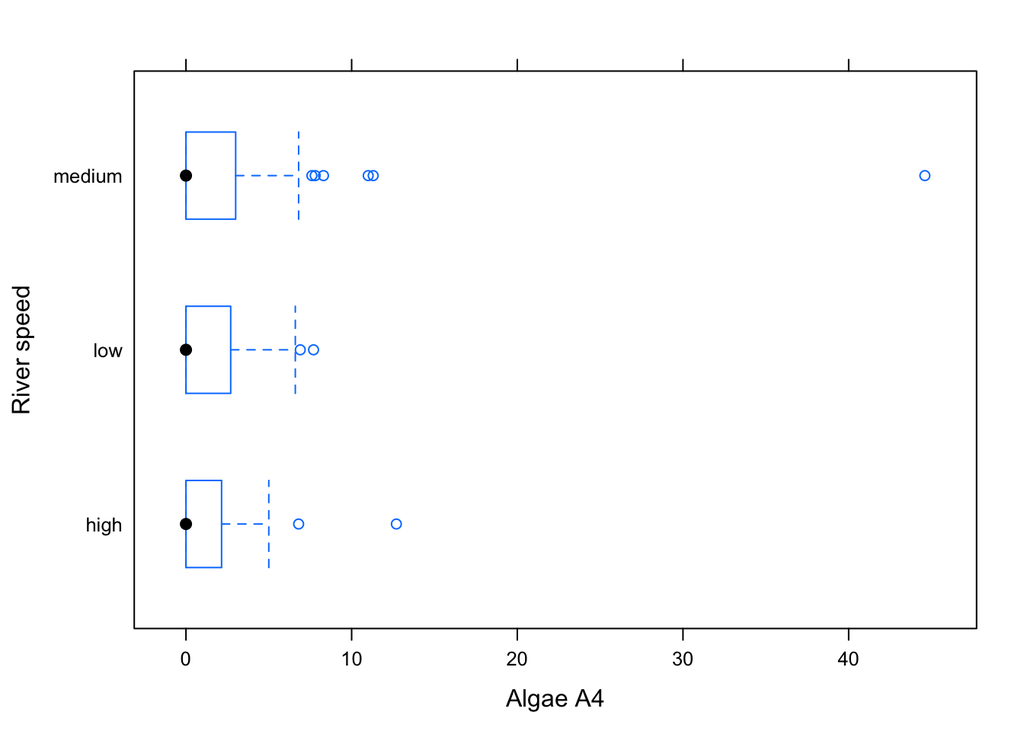

```r
bwplot(speed~a4,data=algaeDataset,xlab = "Algae A4",ylab = "River speed")
```

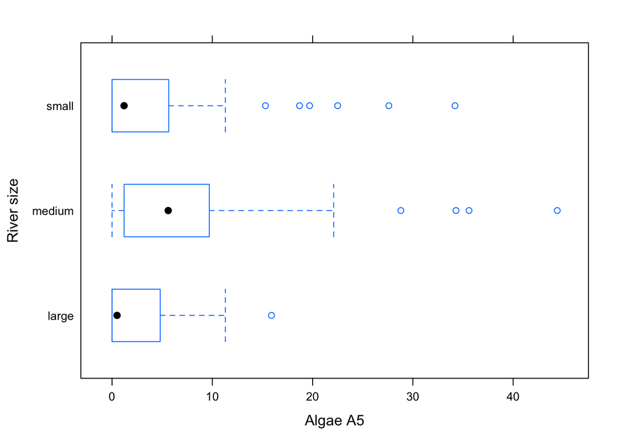

```r
bwplot(size~a5,data=algaeDataset,xlab = "Algae A5",ylab = "River size")
```

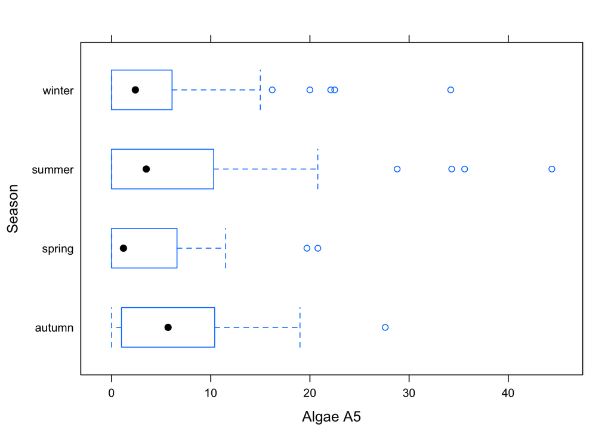

```r
bwplot(season~a5,data=algaeDataset,xlab = "Algae A5",ylab = "Season")
```

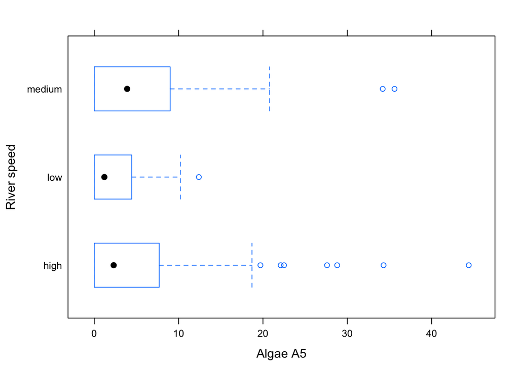

```r
bwplot(speed~a5,data=algaeDataset,xlab = "Algae A5",ylab = "River speed")
```

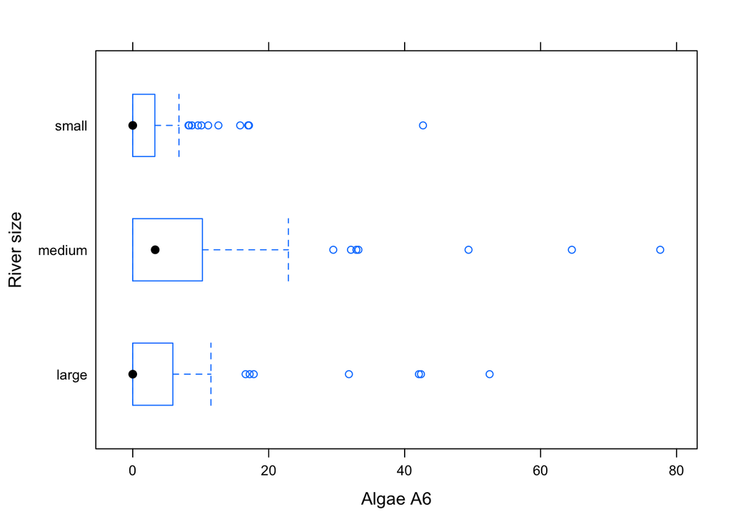

```r
bwplot(size~a6,data=algaeDataset,xlab = "Algae A6",ylab = "River size")
```

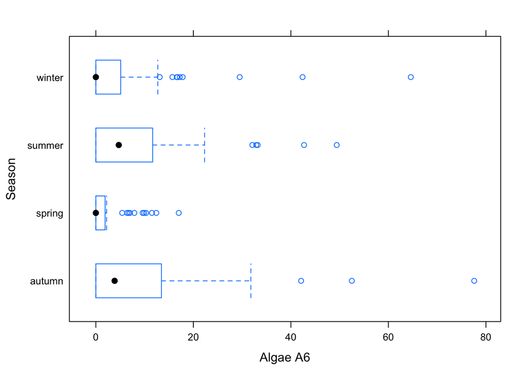

```r
bwplot(season~a6,data=algaeDataset,xlab = "Algae A6",ylab = "Season")
```

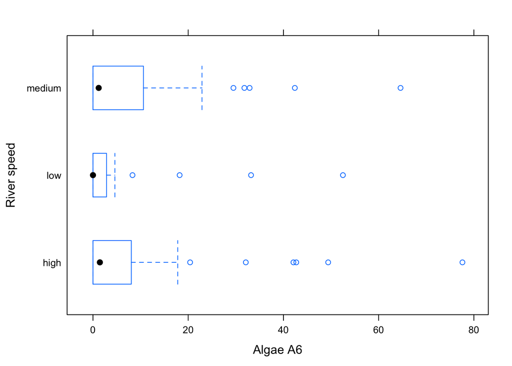

```r
bwplot(speed~a6,data=algaeDataset,xlab = "Algae A6",ylab = "River speed")
```

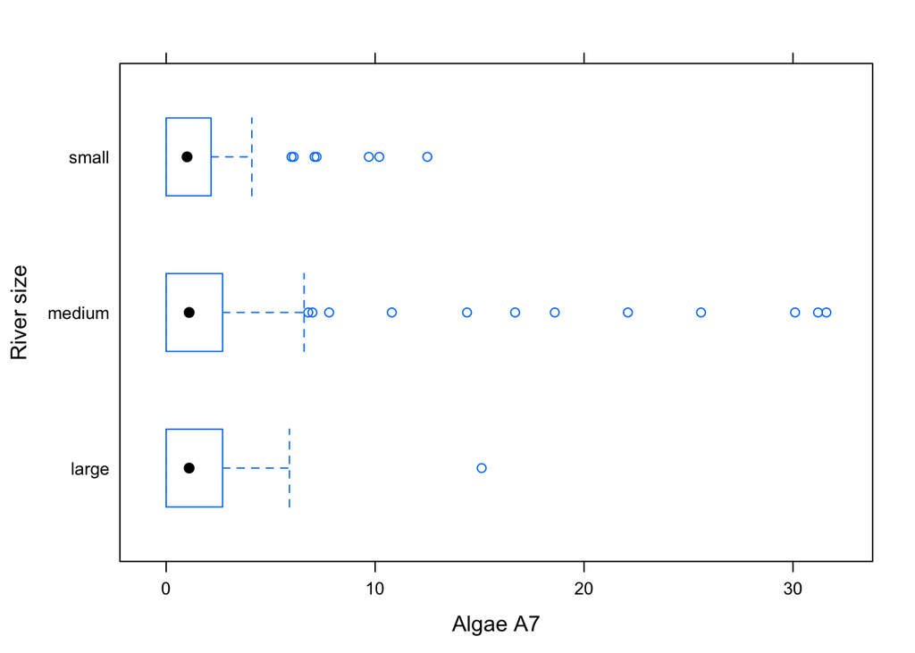

```r
bwplot(size~a7,data=algaeDataset,xlab = "Algae A7",ylab = "River size")
```

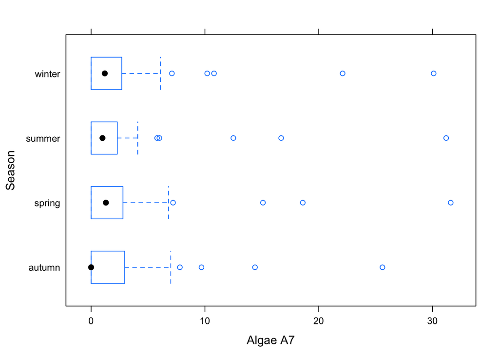

```r
bwplot(season~a7,data=algaeDataset,xlab = "Algae A7",ylab = "Season")
```

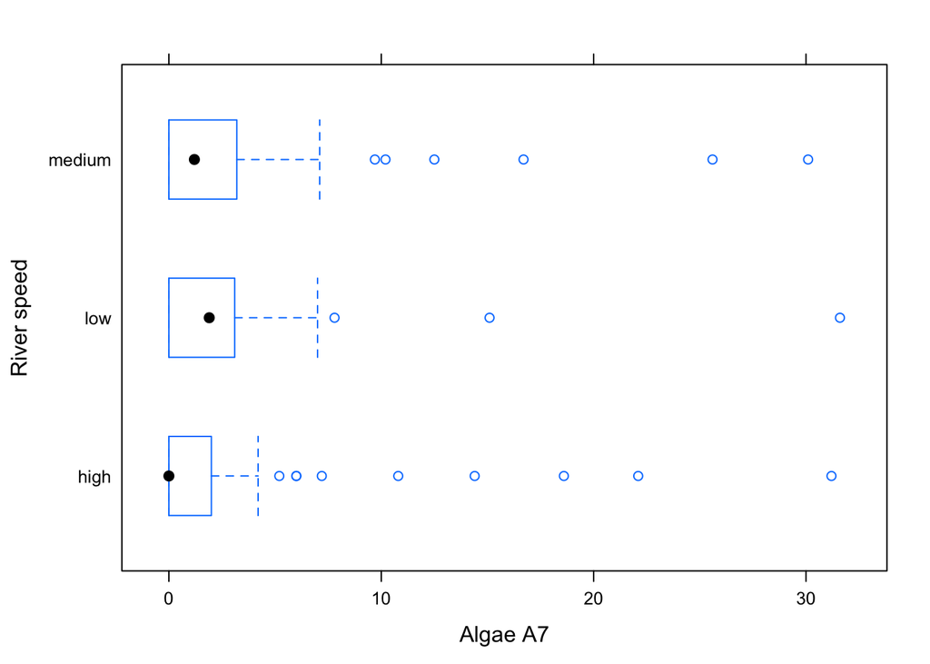

```r
bwplot(speed~a7,data=algaeDataset,xlab = "Algae A7",ylab = "River speed")
```

# Multivariate Normal distribution check:

Here we have calculated covriance and column Means for the normal distribution check

```r
colnames(algaeDataset)
```

```
##  [1] "season" "size"   "speed"  "mxPH"   "mnO2"   "Cl"     "NO3"
##  [8] "NH4"    "oPO4"   "PO4"    "Chla"   "a1"     "a2"     "a3"
## [15] "a4"     "a5"     "a6"     "a7"
```

```r
x <- dist(scale(algaeDataset[, c("mxPH", "mnO2", "Cl","NO3","NH4","oPO4","PO4","Chla")],
center = FALSE))
as.dist(round(as.matrix(x), 2)[1:12, 1:12])
```

```
##       1    2    3    4    5    6    7    8    9   10   11
## 2  3.99
## 3  1.47 3.32
## 4  2.25 3.75 1.36
## 5  1.89 4.26 1.29 1.73
## 6  1.45 4.68 1.51 2.04 0.98
## 7  2.18 3.81 1.23 0.63 1.78 1.90
## 8  1.91 4.09 0.99 0.95 1.09 1.27 0.76
## 9  2.41 4.15 1.62 1.01 2.04 2.25 1.13 1.25
## 10 2.54 4.30 1.55 1.33 1.98 2.13 1.10 1.11 0.78
## 11 2.59 4.47 1.67 1.42 2.00 2.11 1.18 1.14 0.86 0.19
## 12 2.61 4.50 1.67 1.49 2.01 2.09 1.19 1.14 1.01 0.28 0.17
```

```r
x <- algaeDataset[, c("mxPH", "mnO2", "Cl","NO3","NH4","oPO4","PO4","Chla")]
cm <- colMeans(x)
S <- cov(x)
d <- apply(x, MARGIN = 1, function(x)t(x - cm) %*% solve(S) %*% (x - cm))
d
```

```
##          1          2          3          4          5          6
##   6.308049  19.106097   2.421095   5.180995  10.294317   7.399293
##          7          8          9         10         11         12
##   2.041773   1.378710  12.205272   1.197181   1.921584   3.798214
##         13         14         15         16         17         18
##   8.532871   2.830503   1.439196   5.165389   2.622491   1.825596
##         19         20         21         22         23         24
##   3.608542  58.031899  25.777324   6.083269   1.293435   2.409365
##         25         26         27         29         30         31
##   1.691277   1.445833   7.016084   1.342879   6.862262   5.058512
##         32         33         34         35         36         37
##   7.307562   1.909092   8.632794  31.685679   4.697365   2.824579
##         39         40         41         42         43         44
##   3.936960   3.833429   7.125914   1.908280  13.210620  13.131659
##         45         46         47         49         50         51
##   5.733295   5.061218   2.986639   2.483175   5.431851   1.859074
##         52         53         54         64         65         66
##   2.127574   1.951258   2.090195   2.905784   6.098314   3.784768
##         67         68         69         70         71         72
##   6.337565   8.800744  13.830102  13.513559   4.687019   4.334381
##         73         74         75         76         77         78
##   8.476801   4.075346   4.546652  10.461680   1.733699   3.403869
##         79         80         81         82         83         84
##   8.807962   2.613294   2.985317   4.259104   4.981331   4.304431
##         85         86         87         88         89         90
##   3.437738   3.278232   4.128853  25.149504  39.506861   5.501486
##         91         92         93         94         95         96
##  13.788324   4.286977   4.112380   2.979496   4.062759   5.674828
##         97         98         99        100        101        102
##  11.629657  22.127963   6.699621   7.079427   5.779818   6.160962
##        103        104        105        106        107        108
##   5.127619  10.636963  23.437896  12.990154  19.350300   2.124670
##        109        110        111        112        113        114
##   2.776525   1.604639   4.785924   2.079407   3.877778   3.800045
##        115        117        118        119        120        121
##   2.172866   4.962100   2.967282   6.686641   6.390291   6.210870
##        122        123        124        125        126        127
##   3.344137   5.729451   3.735153   1.605119   3.616362  23.986556
##        128        129        130        131        132        133
##  24.607705   4.143984   2.100551   2.340132   4.518660  22.476839
##        134        135        136        137        138        139
##  63.942596   8.603364   4.850736   2.216286   2.455642   2.940920
##        140        141        142        143        144        145
##   6.700856   4.176732   1.403138   1.257009  11.020921  12.375073
##        146        147        148        149        150        151
##  14.543299   1.467437   1.348421   1.598294   4.391603   4.050456
##        152        153        154        155        156        157
##   7.058305 161.168546   8.288272   5.881847   8.468986  15.397865
##        158        159        160        162        163        164
##   7.938589   1.610956   3.237650  21.289695  21.783274  20.149452
##        165        166        167        168        169        170
##   3.879358   4.280981   9.466264   2.935196   6.357279   5.180706
##        171        172        173        174        175        176
##   7.223011  16.399980   2.507884   2.278454  16.633284  14.495956
##        177        178        179        180        181        182
##   4.928755   2.053170   2.780939   4.186970   2.277912   3.296089
##        183        185        186        187        188        189
##   2.185410   1.490406   6.266247   3.768446   1.625527   2.158205
##        190        191        192        193        194        195
##   2.233151   4.644156   1.825111   3.490051   2.398118   3.397172
##        196        197        198        200
##   3.264242   1.595691   7.517249   2.631665
```

```r
S
```

```
##              mxPH         mnO2         Cl          NO3          NH4
## mxPH    0.2225065   -0.1166057    3.26578   -0.3146066    -147.8650
## mnO2   -0.1166057    5.7944078  -29.82509    1.0997298    -382.7583
## Cl      3.2657796  -29.8250876 2215.30207   38.4726809    6309.3683
## NO3    -0.3146066    1.0997298   38.47268   15.0133862    5704.5208
## NH4  -147.8649973 -382.7582810 6309.36826 5704.5208456 4127337.0433
## oPO4    3.9421181  -87.7889395 1653.33413   47.7364490   41267.4404
## PO4     6.1710802 -144.1914158 2705.30776   78.5551787   52300.3410
## Chla    4.1277801   -6.4007720  136.35243   11.4240425    3754.8089
##              oPO4         PO4        Chla
## mxPH     3.942118     6.17108    4.127780
## mnO2   -87.788939  -144.19142   -6.400772
## Cl    1653.334129  2705.30776  136.352430
## NO3     47.736449    78.55518   11.424043
## NH4  41267.440358 52300.34101 3754.808912
## oPO4  8578.739540 10905.44454  200.672650
## PO4  10905.444542 16668.91384  650.137379
## Chla   200.672650   650.13738  410.655232
```

```r
cm ##from the column means we can say that mxPH,mnO2,NO3 and Chla are related because the column means are close enough
```

```
##       mxPH       mnO2         Cl        NO3        NH4       oPO4
##   8.078288   9.018587  44.880886   3.384071 537.671598  78.269446
##        PO4       Chla
## 146.577647  13.882799
```

## Now let us draw the normal Q-Q plot for all the chemicals observed in the river

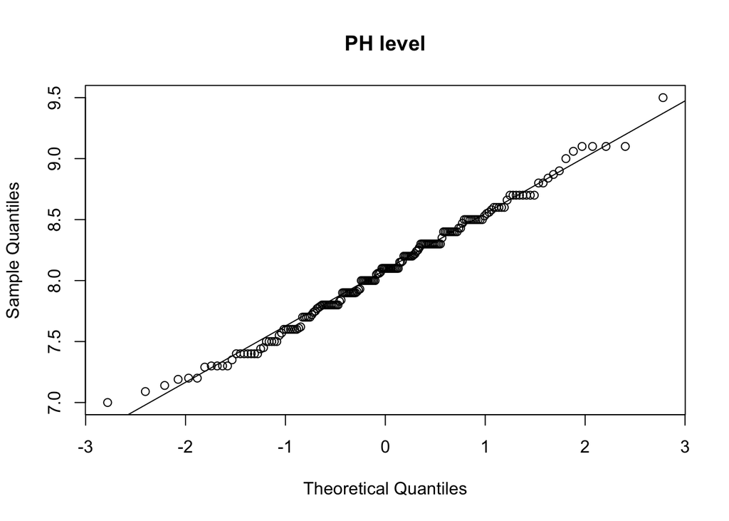

```r
{qqnorm(algaeDataset[,"mxPH"], main = "PH level")
  qqline(algaeDataset[,"mxPH"])}
```

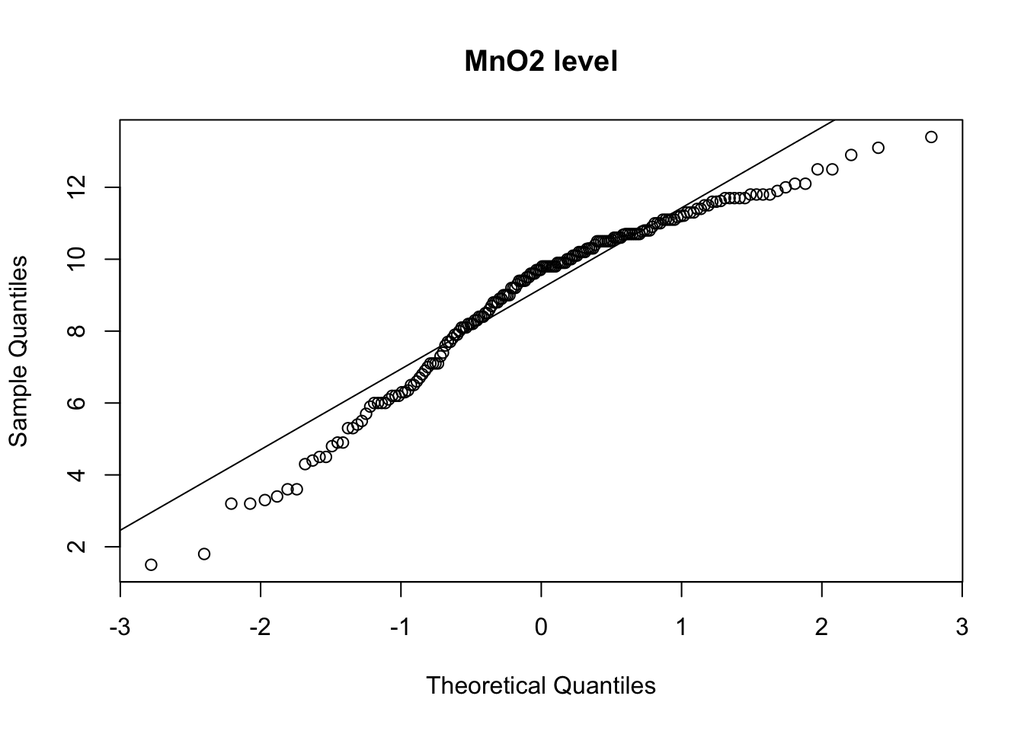

```r
{qqnorm(algaeDataset[,"mnO2"], main = "MnO2 level")
  qqline(algaeDataset[,"mnO2"])}
```

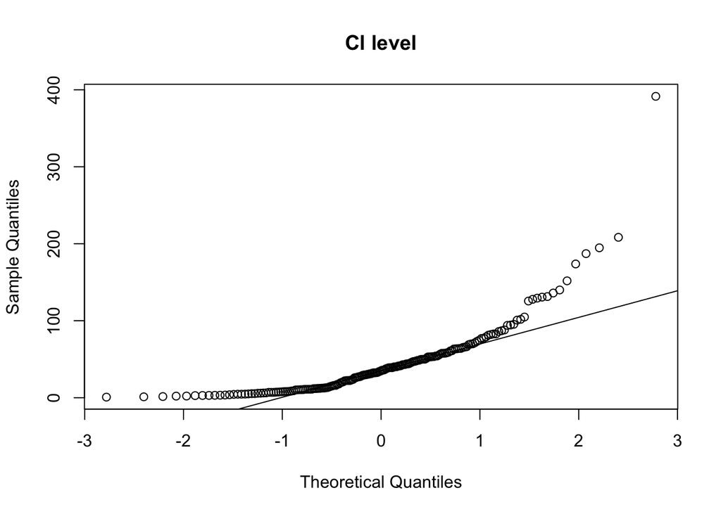

```r
{qqnorm(algaeDataset[,"Cl"], main = "Cl level")
  qqline(algaeDataset[,"Cl"])}
```

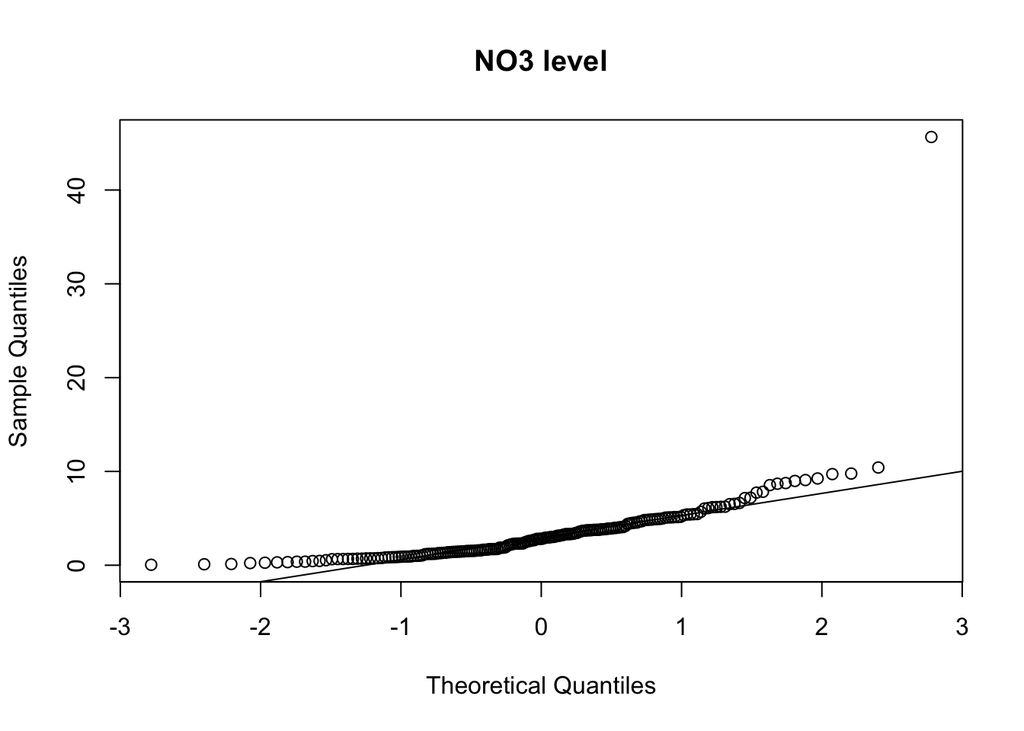

```r
{qqnorm(algaeDataset[,"NO3"], main = "NO3 level")
  qqline(algaeDataset[,"NO3"])}
```

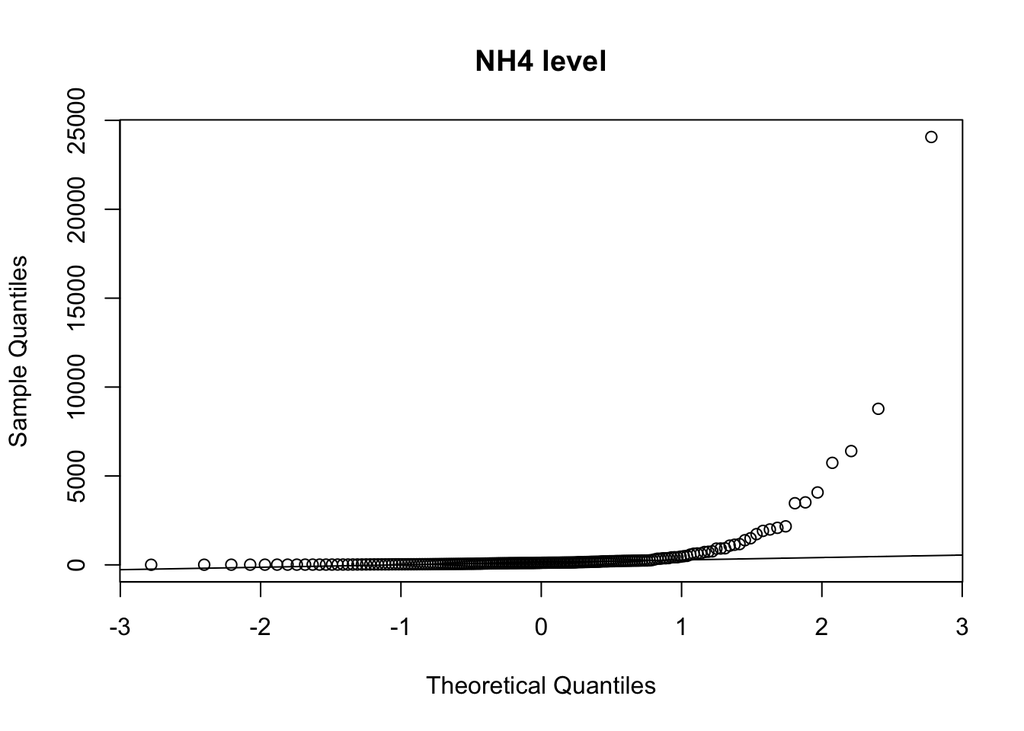

```r
{qqnorm(algaeDataset[,"NH4"], main = "NH4 level")
  qqline(algaeDataset[,"NH4"])}
```

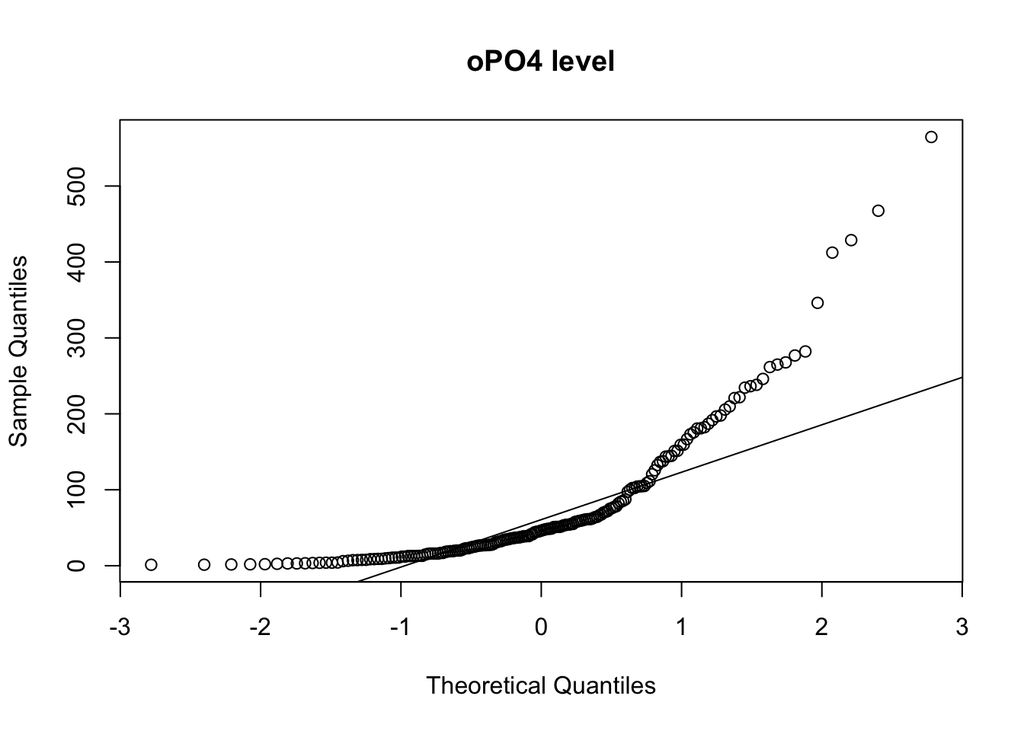

```r
{qqnorm(algaeDataset[,"oPO4"], main = "oPO4 level")
  qqline(algaeDataset[,"oPO4"])}
```